# SI618 HW2

Joshua Gardner

March 16, 2016

# Loading and Cleaning Data (5 points)

First the TSV data file created in part 1 is loaded into a R data frame using the **read.table()** function. The city, state and main_category columns should be converted to factors. Then listwise deletion (http://en.wikipedia.org/wiki/Listwise_deletion) is applied to remove records with missing data (use the **na.omit()** function). Here is the summary of the data frame:

```
##      name                         city          state          stars
##  Length:13137       Los Angeles     : 944   CA     :3917   Min.   :1.000
##  Class :character   Cambridge       : 924   NY     :1336   1st Qu.:3.000
##  Mode  :character   Austin          : 493   MA     :1240   Median :3.500
##                     Houston         : 492   TX     : 987   Mean   :3.628
##                     Berkeley        : 491   PA     : 979   3rd Qu.:4.500
##                     San Luis Obispo : 491   NC     : 494   Max.   :5.000
##                     (Other)         :9302   (Other):4184
##   review_count             main_category
##  Min.   :   2.00   Food           :1658
##  1st Qu.:   3.00   Shopping       : 502
##  Median :   7.00   Local Services : 446
##  Mean   :  26.86   Active Life    : 401
##  3rd Qu.:  21.00   Hair Salons    : 369
##  Max.   :2874.00   Hotels & Travel: 352
##                    (Other)        :9409
```

# Histograms of Star Ratings (10 points)

Histograms of star ratings are plotted with the **qplot()** function. Both actual counts and density plot are shown. (Use **binwidth=1)**

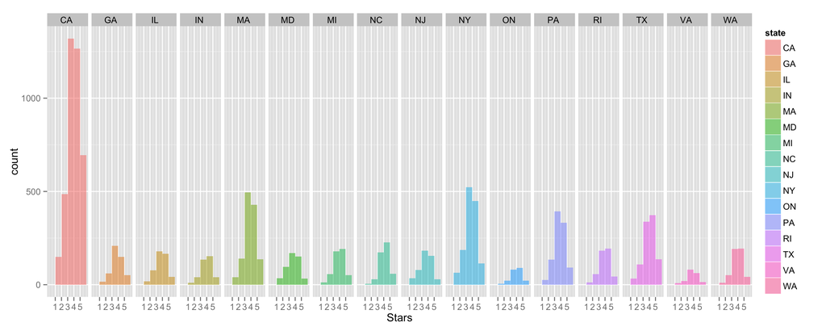

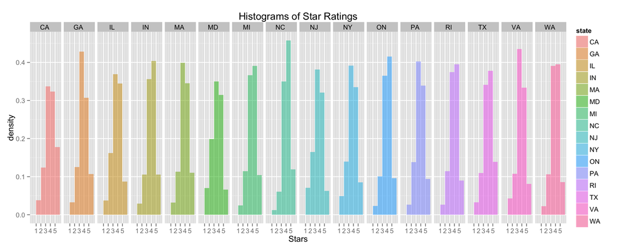

# Histograms of Review Counts (10 points)

Histograms of review counts are plotted with the **qplot()** function. (Use **binwidth=10**)

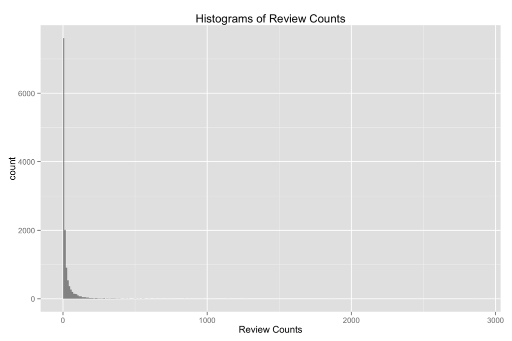

We can see that the distribution of review counts has a long tail. To zoom in on the bars to the left of the 200 mark, we use the **subset()** function to select just the data with review count <= 200. And then plot the histogram again with **binwidth=1**.

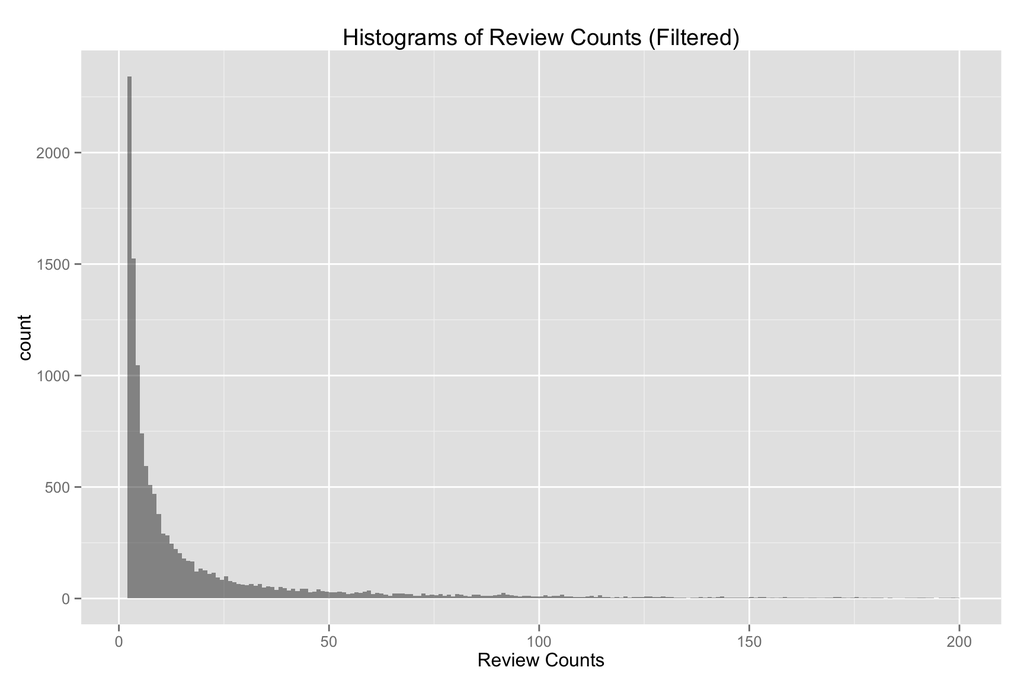

# Boxplot of Star Ratings by States (10 points)

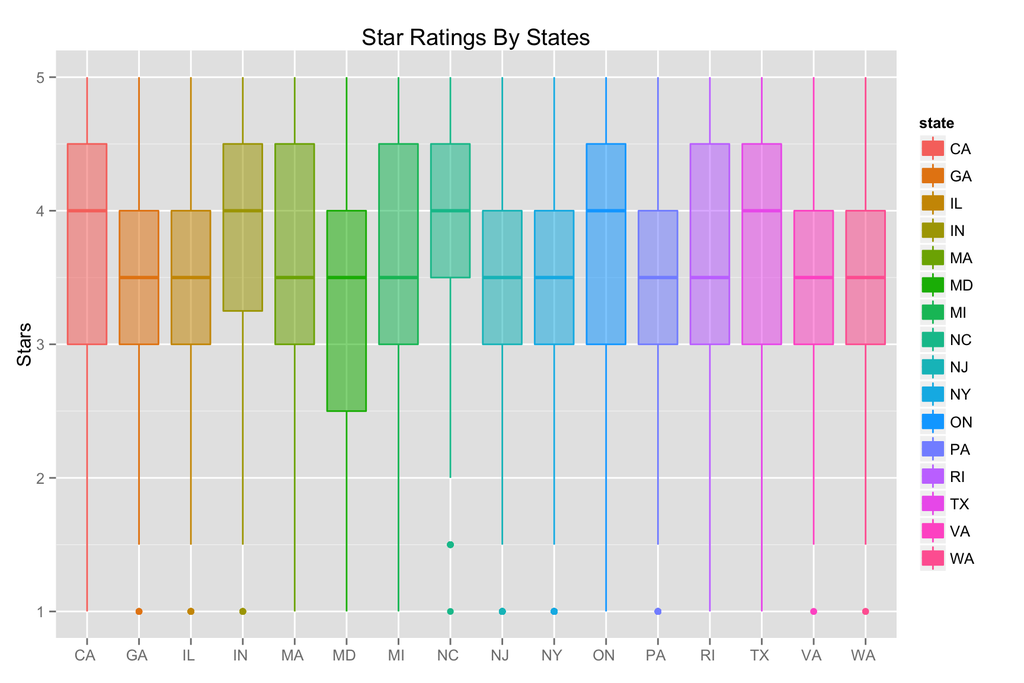

# Jittered Plot of Star Ratings by States (10 points)

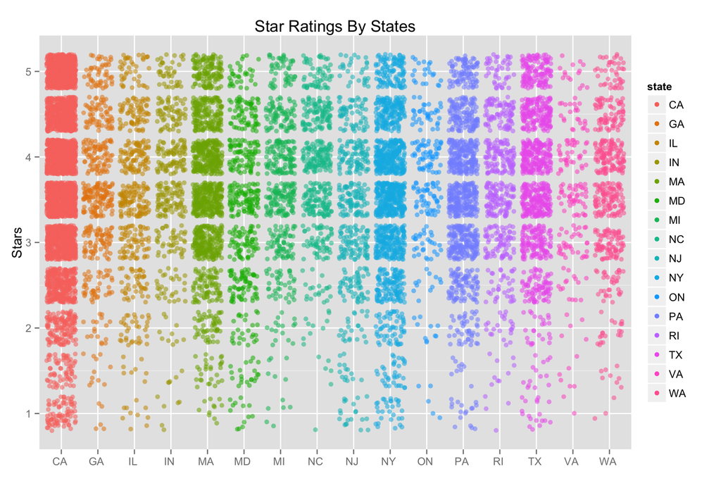

# Bar Chart of Number of Businesses by State (10 points)

The states should be orderd by descreading height of bars.

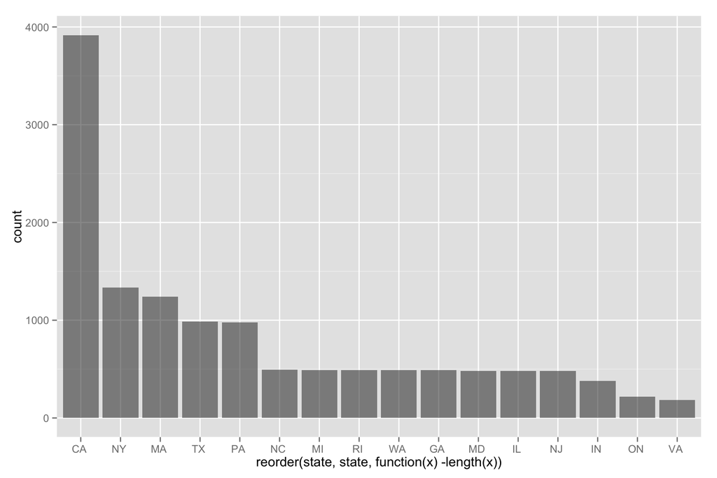

# Jittered Scatterplot of Stars and Review Counts (10 points)

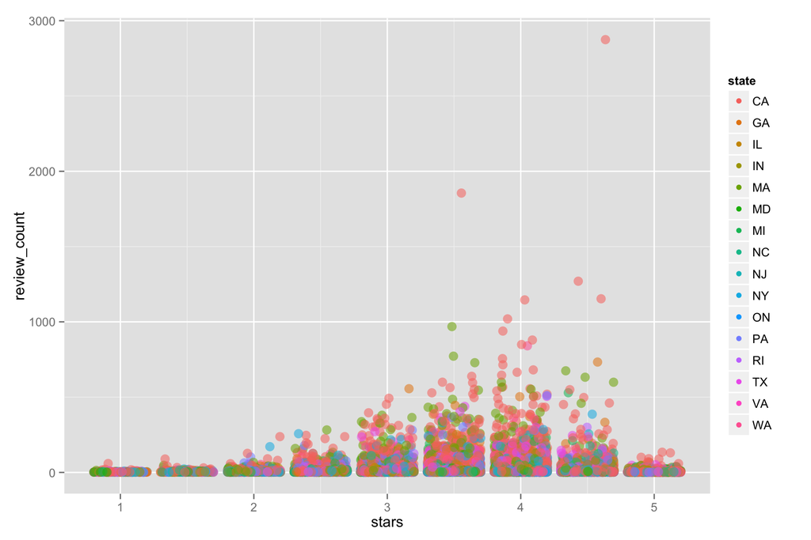

# Slice and Dice Data with plyr

## Subsetting Data (10 points)

We first rank the business in each city for each main category. Then top 5 ranked businesses in each city for each main category are found. We are interested in is the top 5 business with main category of “Chinese” in each city. The data should be ordered by city names, and then by ranks. The result is listed below.

```
##                    city                                        name rank
## 1              Amherst                        Amherst Chinese Food     1
## 2              Amherst                               China Dynasty     2
## 3            Ann Arbor                                  Kai Garden     1
## 4            Ann Arbor                       China Gate Restaurant     2
## 5            Ann Arbor                                       TK Wu     3
## 6            Ann Arbor  Lucky Kitchen Chinese Carry-Out & Delivery     4
## 7            Arlington                                 Jade Garden     1
## 8              Atlanta                   Mu Lan Chinese Restaurant     1
## 9              Atlanta                               Chinese Budda     2
## 10             Atlanta                             Mandarin Palace     3
## 11              Austin                                   Yen Ching     1
## 12              Austin                          Sunhing Restaurant     2
## 13              Austin                                   Magic Wok     3
## 14            Berkeley                                Happy Valley     1
```

[output cut: 271 more lines]

# Summarize Data (10 points)

Next, we compute the mean review counts of all businesses for each state and plot the bar chart below.

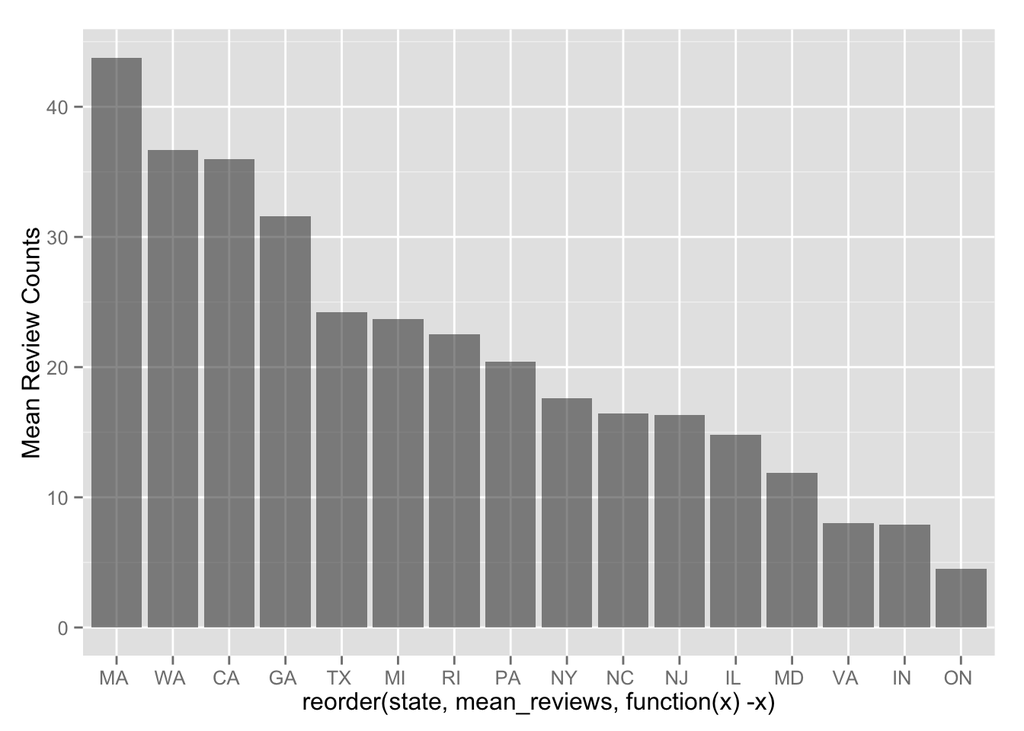

```r
meanreviews = ddply(yelpdata, .(state), summarise, mean_reviews = mean(review_count))
qplot(reorder(state, mean_reviews, function(x)-x), mean_reviews, data = meanreviews, geom = "bar", stat = "identity", alpha = 0.5) + scale_alpha(guide = 'none') + ylab("Mean Review Counts")
```